# Estimación estadística del Ancho de Banda Efectivo

Natalia Clivio

2015

El ancho de banda efectivo es una medida usada en el dimensionamiento y planeamiento de redes de comunicaciones modernas. El objetivo de este análisis, es estimar el ancho de banda efectivo para distintos modelos de tráfico y compararlo con la traza conocida como la de Bellcore y ver que modelo se ajusta al comportamiento de la traza.

En cuanto a su estimación hay dos enfoques, el paramétrico y el no paramétrico. En el enfoque paramétrico se asume un modelo de la fuente de tráfico y a partir de las trazas se estima un conjunto de parámetros de dicho modelo. De esa forma se obtiene un estimador del ancho de banda efectivo y además es posible calcular su intervalo de confianza. En el enfoque no paramétrico, no se asume un modelo específico del tráfico y se procura construir un estimador del ancho de banda efectivo calculando el valor esperado que aparece en la función generatriz de momentos a través de promedios temporales en la traza.

El presente análisis, se realiza con un enfoque paramétrico donde se trabaja con la traza conocida de Bellcore, modelos sencillos como el movimiento browniano, seguido de Fluido de Markov ON/OFF, movimiento fraccional browniano y modelo de FARIMA ya que estos modelos presentan una variadad de características observadas en muchas formas en el tráfico real.

## Traza de Tráfico Ethernet

#### Traza Bellcore

Esta traza de tráfico de BELLCORE labs, esta traza contiene 1000000 de paquetes y se encuentran en dos columnas, en formato ASCII, veinte bytes por línea. La primera línea muestra el tiempo en segundos desde el comienzo de la traza. La segunda columna muestra el tamaño del paquete en bytes, incluyendo parte del encabezado y el código de redundancia cíclica (CRC), tener encuenta que que con el protocolo Ethernet los paquetes poseen un tamaño mínimo de 64 bytes y un máximo de 1.518 bytes.

La traza Bc-pAug89 comienza a las 11:25 el 29 de agosto de 1989, capturó datos alrededor de 3.142,82 s (aproximadamente 1.000.000 paquetes fueron capturados).

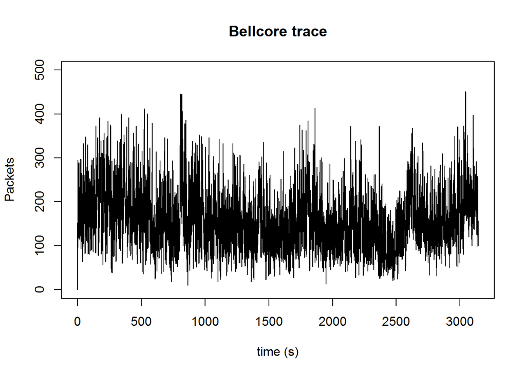

Para los experimentos a continuación, se emplearán trazas con una longitud de 512.

## Procesos de Renovación: Modelos con Incrementos Independientes

#### Flujo con Movimiento Browniano

El movimiento browniano se ha utilizado como un caso limitado del tráfico pesado y también proporciona un inicio al análisis para el tráfico de movimiento browniano fraccional tratado más adelante.[1]

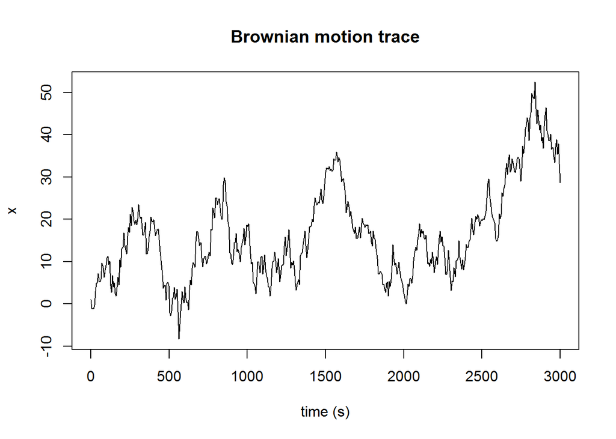

Taza promedio de arribo $\hat{\mu} = 50.83$ Varianza de la taza de arribo $\hat{\theta^2} = 30.18$

El flujo tiene una taza de servicio de C=52, un buffer de tamaño B=5.

Calculando el punto crítico $\boldsymbol{\alpha(s,t)}$, que está determinado por: [1]:

$\alpha(s,t)=\mu + \frac{(s\theta^2)}{2}$

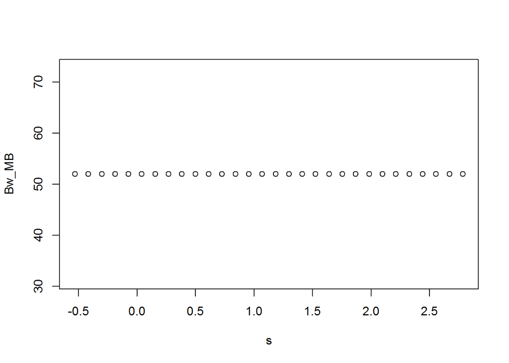

```r
C<-52 #tasa de servicio
u<-seq(length=30, from=10, to=60) #tasa promedio de arribos #50,83
var<-30.18

s<-(2*(C-u))/var

Bw_MB<-u+((s*var)/2)
plot(s,Bw_MB)
```

## Modelos dependientes con rango corto (SRD)

#### Flujo de markov discreto ON/OFF

Se supone un conjunto de fuentes que alternan periodos on/off y que exhiben el efecto “Noah” (síndrome de varianza infinita). El periodo ON es aquel en el se transmite información a velocidad constante y el periodo OFF corresponde al tiempo entre transmisiones. Este el flujo de tráfico agregado no presenta cor- relación a largo plazo.

Si el flujo Markoviano modulado por una cadena de Markov con dos estados 0 (OFF) y h (ON). Mientras la cadena está en el estado h se produce trabajo a tasa constante h, mientras está en el estado 0 no se produce trabajo. El generador infinitesimal de la cadena es la matriz Q y H es una matriz diagonal con elementos hi en la diagonal[4]:

$Q = \begin{pmatrix} -\lambda & \lambda \\ \mu & -\mu\end{pmatrix}$

$H = \begin{pmatrix} 0 & 0 \\ 0 & h\end{pmatrix}$

donde $\lambda$¸ se interpreta como la cantidad de transiciones del estado 0 al estado h por unidad de tiempo y $\mu$ como la cantidad de transiciones que salen de 0 por unidad de tiempo. $\vec{\pi}$ es la distribución estacionaria de la cadena, este es un vector de probabilidad $\pi$ tal que $\pi Q =\vec{0}$ , la distribución invariante de la cadena es:

$\pi =\left(\frac{\mu}{\lambda + \mu};\frac{\lambda}{\lambda + \mu}\right)$

Tomando como distribución inicial de la cadena la distribución invariante, el ancho de banda efectivo que resulta es:

$\boldsymbol{\alpha(s,t)=log\{ \vec{\pi} exp[(Q + Hs) t] \vec{1} \}}$

Reemplazando, se obtiene:

$\alpha(s,t)=$ $log\{(\frac{\mu}{\lambda + \mu};\frac{\lambda}{\lambda + \mu})$ $exp(\begin{smallmatrix} -\lambda & \lambda \\ \mu & -\mu\end{smallmatrix})$ $t \vec{1} \}$

Calculando el ancho de banda $\alpha(s,t)$:

```r
#library(rgl)

l<-0.4#0.01012  #0.4
u<-0.3#0.01034  #0.3
h<-3#0.01     #3
Q<-matrix(c(-l,u,l,-u),2,2)
H<-matrix(c(0,0,0,h),2,2)
V<-matrix(1,2,2)
```

```r
Q
```

```
##      [,1] [,2]
## [1,] -0.4  0.4
## [2,]  0.3 -0.3
```

```r
H
```

```
##      [,1] [,2]
## [1,]    0    0
## [2,]    0    3
```

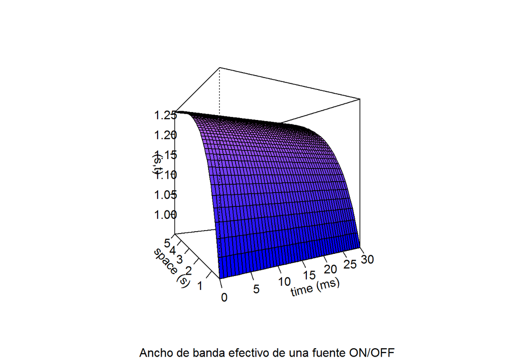

```r
#Distribución invariante es un vector de probabilidad pi tal que piQ=0, entonces:
pi1<-l/(l+u)
pi2<-u/(l+u)

space<-seq(length=50, from=0.5, to=5) #0.5 to 5 0 to 4000
time<-seq(length=50, from=0, to=30) #ms 1 to 30 1 to 20
s<-(space)
t<-(time)

Bw<-function(t,s) {(1/s)*log10(pi2+(exp((h*s))*pi1))}
z<-outer(t,s,Bw)     # La función outer evalua la función Bw en cada punto(si,tj)

nrz<-nrow(z)
ncz<-ncol(z)

# Create a function interpolating colors in the range of specified colors
jet.colors<-colorRampPalette(c("blue","violet"))

# Generate the desired number of colors from this palette
nbcol<-100
color<-jet.colors(nbcol)
# Compute the z-value at the facet centres
zfacet<-z[-1,-1]+z[-1,-ncz]+z[-nrz,-1] +z[-nrz,-ncz]

# Recode facet z-values into color indices
facetcol<-cut(zfacet,nbcol)

persp(t,s,z,theta=-30,phi=0,col = color[facetcol],
      sub="Ancho de banda efectivo de una fuente ON/OFF",
      ticktype = "detailed",xlab="time (ms)",ylab="space (s)",zlab="(s,t)")
```

## Modelos dependientes con rango largo (LRD)

#### Movimiento fraccional browniano

El movimiento browniano fraccional es un proceso Gaussiano BH(t) de media cero con autosimilitud perfecta, con parámetro H que, a diferencia del modelo M/Pareto, se extiende entre 0 y 1. El movimiento browniano es utilizado en eldimensionado de recursos, el cálculo del retardo extremo a extremo y el multiplexado de fuentes de tráfico.[2]

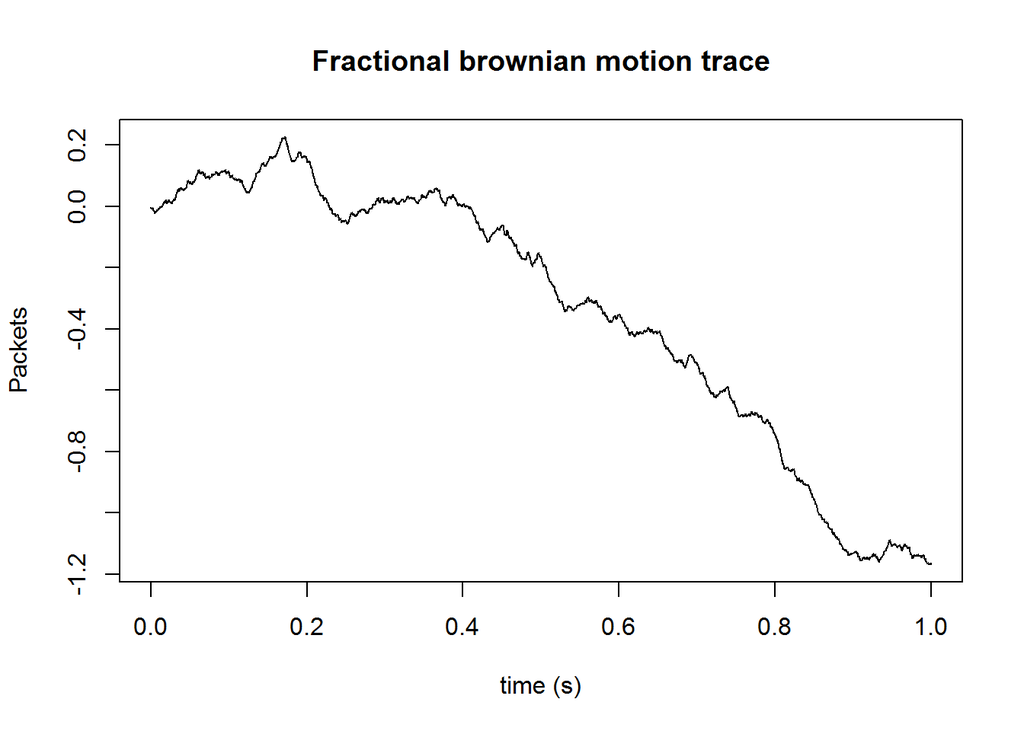

Teniendo en cuenta las características autosimilares de esta traza de tráfico y que siga un modelo de movimiento fraccional browniano, entonces se puede suponer para el modelo una llegada de los datos en intervalos de tiempo t dada por:

$X[\tau,\tau+t]=\lambda t+Z(t)$

donde Z(t) corresponde al movimiento fraccional browniano con Var[Z(t)]=o^2*t^(2*H) para un parámetro de HURTS *H* entre 0 y 1, entonces[3]:

$\alpha(s,t)=\lambda + \frac{\theta^2 t^{(2H-1)}}{2}s$

Taza promedio de arribo $\hat{\mu} = 35.09$ Varianza de la taza de arribo $\hat{\theta^2} = 25.53$

El flujo tiene una taza de servicio de C=37, un buffer de tamaño B=5.

Calculando el ancho de banda efectivo, se obtiene:

```r
#Ejemplo 2
#Cálculo estadístico del ancho de banda efectivo de la traza
l<-138.185 #bytes por segundo
var<-89.668^2 # varianza
H<-0.81
t<-(seq(length=100, from=0.0001, to=10))    #time parameter (ms)
s<-(seq(length=100, from=0.00001, to=0.01)) #space parameter (bytes^-1)
```

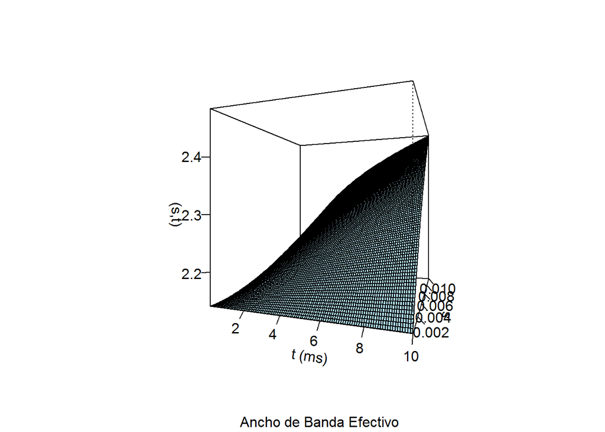

```r
Bw<-function(t,s) {log10(l+((((o^2)*(t^((2*H)-1)))/2)*s))}
z<-outer(t,s,Bw) # La función outer evalua la función Bw en cada punto(si,tj)

persp((t),(s),(z),theta=20,phi=-0,col ="lightblue", sub="Ancho de Banda Efectivo",ticktype ="detailed",xlab="t (ms)",ylab="s",zlab="(s,t)")
```

Calculando el punto crítico $\boldsymbol{\alpha(s,t)}$

```r
#Ejemplo 1
#Cálculo analítico del ancho de banda efectivo de la traza
C<-37
B<-5
u<-35.09
var<-25.53
H<-0.75

t<-(B/(C-u))*(H/(1-H))      #8
s<-(B+(C+u)*t)/(var*t^(2*H)) #0.0355


Bw_MFB<-u+(((s*var)/2)*(t^(2*H-1)))
Bw_MFB
```

```
## [1] 71.45
```

## Procesos de Colas pesadas, autosimilares y LRD

#### $\alpha$-Stable Farima

Este modelo se usa en el estudio de las redes modernas de tráfico,con tendencia a incrementos con colas pesadas y procesos de dependencia de rango largo.

Considerando un flujo de longitud 512 con dependencia de rango largo y con incrementos de cola pesada. Con parámetros:

Taza promedio de arribo $\hat{\mu} = 24.968$ Varianza de la taza de arribo $\hat{\theta^2} = 4.058$

El flujo tiene una taza de servicio de C=25, un buffer de tamaño B=4.Como no hay una fórmula para determinar el punto crítico, se emplea la misma del movimiento browniano

Calculando el ancho de banda efectivo, se obtiene: $\alpha(s,t)=\mu + \frac{(s*\theta^2)}{2}$

```r
C<-25
B<-4
u<-24.968
var<-4.058

s<-(2*(C-u))/var
t<-B/(C-u)

Bw_MB<-u+((s*var)/2)
Bw_MB
```

```
## [1] 25
```

El valor esperado es que el ancho de banda efectivo sea sustancialmente mayor que la taza promedio de arribo, por lo tanto se debería usar otro estimador para hacer el cálculo.

## Ancho de banda de traza de tráfico real

### Traza Bellcore

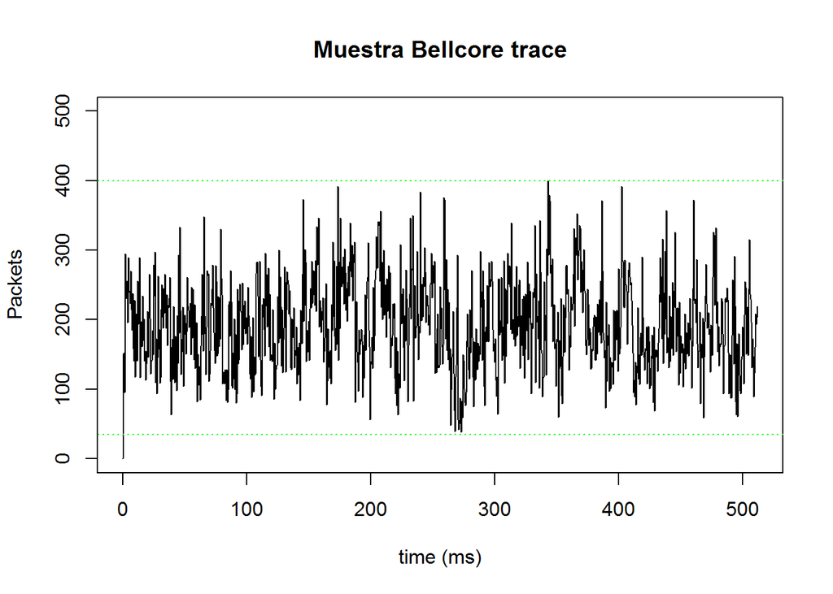

Considerando los parámetros: Taza promedio de arribo $\hat{\mu} = 1.591$ Varianza de la taza de arribo $\hat{\theta^2} = 4.169$

**Estimador de movimiento browniano.**

Calculando el punto crítico $\boldsymbol{\alpha(s,t)}$, que está determinado:

```r
C<-2.9
B<-0.3
u<-1.591
var<-4.169

s<-(2*(C-u))/var
t<-B/(C-u)

Bw_MB<-u+((s*var)/2)
Bw_MB
```

```
## [1] 2.9
```

```r
C<-2.9
B<-0.3
u<-1.591
var<-4.169
H<-0.75
```

Ethernet traffic data from a LAN at Bellcore, Morristown (Leland et al. 1993, Leland and Wilson 1991). The data are listed in chronological sequence by row.